# Mid-term project instructions

Author

Jazib Ali Irfan & Ujjwal Sigdel

# 1 Mid-term project GitHub repository URL:

Paste here the URL of the GitHub project (after going through the instruction steps)

https://github.com/Jazib001/2024dsa_midproject_group1.git

# 2 Instructions

This file contains both the **instructions** for the mid-term project and placeholders for your code. You are required to use this file to produce code, output, and answers to the questions below.

Besides simply creating output, make sure to interpret the output. You will need to create tables and/or plots to arrive at the answers, and then comment on what you found below it.

To get you setup, you will need to:

- Student #1: create a repository on your GitHub account. You can call this repository “2024dsa_midproject_groupX”, **where X is the number of your group**. Make it public, add a README, add a .gitignore for R.
- Student #1: follow the steps we did in class to start a new RStudio project with version control.
- Student #1: in your computer, create the sub-folders code, data, output, and move your data set into the `data` folder. Also, student 1 moves this current script into the `code` folder. Do a git stage, commit, push.
- Student #1: on GitHub, go the repository settings and invite your partner to be a collaborator in the repository. That will give them push permission.
- Now, both students should clone this repository on their computers like we did in class. Make sure this step works well and that you can pull and push from GitHub.
- Student 2, after cloning, does a git pull to get all these updates on their computer.
- Student 1 and 2 work together to update the README file. README files should explain what the repository is about, the goals of that project, who is working in it, and any other important details you may find.

# 3 Introduction

Describe here the introduction of your problem. Consider this as a shortened version of your paper, where you will briefly discuss in 3-4 paragraphs what is the issue/gap in literature, and how the data you collected will help answer this gap.

Answer:

Switchgrass is a C3 perennial forage known for its high adaptation to marginal lands, requires less/no inputs and yields more biomass depending upon ecotype and adaptation. The data used in this analyses was generated to provide a strategy for the selection of high-yielding individual with the end-goal of variety development and release, using genetics and omics approaches. As a well-known bioenergy crop with the potential of producing bioethanol.

It has been the focus of the United States Department of Energy (US-DoE) to utilize forage and tree species growing on marginal lands to be used for bioethanol production to help fight global warming by cutting off excessive atmoshpheric carbon released in the environment using renewable sources of energy like exotic trees and forages where switchgrass is the best choice since past decades .

The study involves the multi-location phenotypic evaluation of half-sib families (HSF) of bioenergy crop switchgrass to select genotypes with higher biomass yield. Genotyping-by-sequencing (GBS) will enable endogenous genome marker evaluation to generate single nucleotide polymorphism (SNP) maps to select the best genotypes based on phenotypic evaluation of progeny.

# 4 Hypothesis and objectives

Describe here your hypothesis, followed by your objectives. Make sure your hypothesis are testable and bold, and objectives are clear.

Answer:

The main objective of the study was to analyze progeny biomass yield over several years, out of which the current data has 2 years of yield recordings and further analysis will be based on analyzing the data for yield variations across years, locations and replications to look for the effect of these factors on the overall yield. Our objective is to record yield of all the progeny population and our hypothsis is based on the yield variation across years and location in Southeastern state of the USA.

# 5 Material and Methods

Describe here your overall material and methods as it pertains to the analysis you will conduct, including study description, site/setup description, what equipment was used, etc. just like you would in a paper. Make sure to clearly explain what was measured and how.

Parental population (polycrosses): The progeny used in the data analysis was obtained from the parental population selected from the fields in Tifton and then grown and outcrossed in Athens. The selection of polycross parents was based on drought tolerance, adaptation to marginal lands with less/no fertilizers and overall dry biomass yield analysis by analyzing the individuals through genome-wide association studies (GWAS) utilizing GBS approach and analyzing SNPs.The corresponding quantitative trait loci (QTL) were used to identify genome regions contributing to the traits of interest (drought tolerance, adaptation and biomass yield). From that GWAS panel 25 early flowering and 25 late flowering individuals were selected, grown in two blocks with 4 replicates in each block in Athens using randomized complete block design (RCBD) by designating the early flowering block as A group (25*4 = 100) and late flowering block as B group (25*4 = 100) and they were allowed to open pollinate. Four seeds were collected from each parent plant and used to develop progeny population.

Progeny Population: The data used for this assignment represents yield variation across the progeny populaton from the above-mentioned polycrosses of a mix of three switchgrass ecotypes collected over the years that are less, moderately and highly adaptable to the Southeastern States of the United States (US). The progeny population comprises of 3200 individuals distributed at two different locations of the Georgia state, Athens and Tifton in a way that each location has half (1600) of the progeny population (equal distribution).

## 5.2 Statistical analysis

# 6 Results

Here is where the coding is going to happen, and it will be completely up to you. Include under this section as many sub-sections (using ##) and as many chunks needed to create the analytical workflow for your analysis, starting at loading packages and data, wrangling, EDA, modeling, assumptions checking, ANOVA table, means, pairwise comparisons, and final publication-quality plot.

Make sure to run a model that reflects your study design. Even if your study design does not include one of the designs covered in class, you are still expected to run the most appropriate model. If you need help for references, let me know.

Before each chunk, describe the steps being performed in that chunk. For example, “Here I will load the data”.

If a chunk produces output, like printing a data frame, statistical summary, a plot, ANOVA table, etc., make sure to write text interpreting what you see and how you can/will use that information to move forward to the next steps in the workflow.

```r
knitr::opts_chunk$set(warning = FALSE, message=FALSE)
```

# 7 Loading packages

```r
# Loading packages
#install.packages("metan")
library(tidyverse) # for data wrangling and plotting
library(janitor) #for clean names
library(car) # for Anova function
library(lme4)
library(broom) # for model residuals extraction
library(emmeans) # for model mean extraction
library(multcomp) # for pairwise comparison letter display
library(multcompView)
library(metan)
```

```r
rcbd_gs <- read_csv("../Data/IHF_TIFT_Combined_2022-23.csv")
head(rcbd_gs, 5)
```

```
# A tibble: 5 × 14
  `Sr. No.`  Year Location Row   Range  Rep   UniqueID HSF   Accn  OriginalAccn
      <dbl> <dbl> <chr>    <chr> <chr>  <chr> <chr>    <chr> <chr> <chr>
1         1  2022 Athens   Row1  Range1 Rep1  A-1-1-1  Fam_1 FID_1 TCL-7
2         2  2022 Athens   Row1  Range2 Rep1  A-1-1-2  Fam_1 FID_2 TCL-7
3         3  2022 Athens   Row1  Range3 Rep1  A-1-1-3  Fam_1 FID_3 TCL-7
4         4  2022 Athens   Row1  Range4 Rep1  A-1-1-4  Fam_1 FID_4 TCL-7
5         5  2022 Athens   Row1  Range5 Rep1  A-1-2-1  Fam_2 FID_5 J249.C
# ℹ 4 more variables: Ecotype <chr>, Yield <dbl>, Notes <chr>,
#   `Whole Harvest` <chr>
```

# 8 b) Exploratory data analysis (EDA)

```r
summary(rcbd_gs)
```

```
    Sr. No.            Year        Location             Row
 Min.   :   1.0   Min.   :2022   Length:6400        Length:6400
 1st Qu.: 800.8   1st Qu.:2022   Class :character   Class :character
 Median :1600.5   Median :2022   Mode  :character   Mode  :character
 Mean   :1600.5   Mean   :2022
 3rd Qu.:2400.2   3rd Qu.:2023
 Max.   :3200.0   Max.   :2023

    Range               Rep              UniqueID             HSF
 Length:6400        Length:6400        Length:6400        Length:6400
 Class :character   Class :character   Class :character   Class :character
 Mode  :character   Mode  :character   Mode  :character   Mode  :character




     Accn           OriginalAccn         Ecotype              Yield
 Length:6400        Length:6400        Length:6400        Min.   :   1
 Class :character   Class :character   Class :character   1st Qu.: 961
 Mode  :character   Mode  :character   Mode  :character   Median :1580
                                                          Mean   :1839
                                                          3rd Qu.:2483
                                                          Max.   :9982
                                                          NA's   :44
    Notes           Whole Harvest
 Length:6400        Length:6400
 Class :character   Class :character
 Mode  :character   Mode  :character
```

```r
glimpse(rcbd_gs)
```

```
Rows: 6,400
Columns: 14
$ `Sr. No.`       <dbl> 1, 2, 3, 4, 5, 6, 7, 8, 9, 10, 11, 12, 13, 14, 15, 16,…
$ Year            <dbl> 2022, 2022, 2022, 2022, 2022, 2022, 2022, 2022, 2022, …
$ Location        <chr> "Athens", "Athens", "Athens", "Athens", "Athens", "Ath…
$ Row             <chr> "Row1", "Row1", "Row1", "Row1", "Row1", "Row1", "Row1"…
$ Range           <chr> "Range1", "Range2", "Range3", "Range4", "Range5", "Ran…
$ Rep             <chr> "Rep1", "Rep1", "Rep1", "Rep1", "Rep1", "Rep1", "Rep1"…
$ UniqueID        <chr> "A-1-1-1", "A-1-1-2", "A-1-1-3", "A-1-1-4", "A-1-2-1",…
$ HSF             <chr> "Fam_1", "Fam_1", "Fam_1", "Fam_1", "Fam_2", "Fam_2", …
$ Accn            <chr> "FID_1", "FID_2", "FID_3", "FID_4", "FID_5", "FID_6", …
$ OriginalAccn    <chr> "TCL-7", "TCL-7", "TCL-7", "TCL-7", "J249.C", "J249.C"…
$ Ecotype         <chr> "Unknown", "Unknown", "Unknown", "Unknown", "Lowland",…
$ Yield           <dbl> 1079, 847, 1549, 790, 741, 1122, 1069, 1222, 416, 710,…
$ Notes           <chr> NA, NA, NA, NA, NA, NA, NA, NA, NA, NA, NA, NA, NA, NA…
$ `Whole Harvest` <chr> NA, NA, NA, NA, NA, NA, NA, NA, NA, NA, NA, NA, NA, NA…
```

# 9 c) Wrangling

```r
# Model 1
rcbd_gsw <- rcbd_gs %>%
  clean_names() %>%
  mutate(year = as.factor(year),
         location = as.factor(location),
         rep = as.factor(rep),
         hsf = as.factor(hsf),
         ecotype = as.factor(ecotype)
         )
head(rcbd_gsw, 5)
```

```
# A tibble: 5 × 14
  sr_no year  location row   range  rep   unique_id hsf   accn  original_accn
  <dbl> <fct> <fct>    <chr> <chr>  <fct> <chr>     <fct> <chr> <chr>
1     1 2022  Athens   Row1  Range1 Rep1  A-1-1-1   Fam_1 FID_1 TCL-7
2     2 2022  Athens   Row1  Range2 Rep1  A-1-1-2   Fam_1 FID_2 TCL-7
3     3 2022  Athens   Row1  Range3 Rep1  A-1-1-3   Fam_1 FID_3 TCL-7
4     4 2022  Athens   Row1  Range4 Rep1  A-1-1-4   Fam_1 FID_4 TCL-7
5     5 2022  Athens   Row1  Range5 Rep1  A-1-2-1   Fam_2 FID_5 J249.C
# ℹ 4 more variables: ecotype <fct>, yield <dbl>, notes <chr>,
#   whole_harvest <chr>
```

```r
## Model 2
rcbd_gsw1 <- rcbd_gs %>%
clean_names() %>%
  mutate(e = paste0(year, "+", location)) %>%
  mutate(g = paste0(accn)) %>%
  mutate(e = as.factor(e),
         rep = as.factor(rep),
         g = as.factor(g),
         ecotype = as.factor(ecotype)) %>%
  arrange(yield) %>%
  group_by(yield)

head(rcbd_gsw1, 5)
```

```
# A tibble: 5 × 16
# Groups:   yield [4]
  sr_no  year location row   range   rep   unique_id hsf     accn  original_accn
  <dbl> <dbl> <chr>    <chr> <chr>   <fct> <chr>     <chr>   <chr> <chr>
1   928  2022 Athens   Row24 Range8  Rep2  A-4-2-4   Fam_32  FID_… J229.A
2  1468  2022 Athens   Row37 Range28 Rep2  B-7-7-4   Fam_167 FID_… J497.C
3  1336  2022 Athens   Row34 Range16 Rep2  C-12-6-4  Fam_134 FID_… J004.B
4  1329  2022 Athens   Row34 Range9  Rep2  B-4-3-1   Fam_133 FID_… J235.A
5   529  2022 Athens   Row14 Range9  Rep1  B-4-3-1   Fam_133 FID_… J235.A
# ℹ 6 more variables: ecotype <fct>, yield <dbl>, notes <chr>,
#   whole_harvest <chr>, e <fct>, g <fct>
```

```r
rcbd_gsw %>%
  group_by(year, location, rep, hsf, yield) %>%
  tally() %>%
head()
```

```
# A tibble: 6 × 6
# Groups:   year, location, rep, hsf [2]
  year  location rep   hsf    yield     n
  <fct> <fct>    <fct> <fct>  <dbl> <int>
1 2022  Athens   Rep1  Fam_1    790     1
2 2022  Athens   Rep1  Fam_1    847     1
3 2022  Athens   Rep1  Fam_1   1079     1
4 2022  Athens   Rep1  Fam_1   1549     1
5 2022  Athens   Rep1  Fam_10   782     1
6 2022  Athens   Rep1  Fam_10   798     1
```

```r
summary(rcbd_gsw)
```

```
     sr_no          year        location        row
 Min.   :   1.0   2022:3200   Athens:3200   Length:6400
 1st Qu.: 800.8   2023:3200   Tifton:3200   Class :character
 Median :1600.5                             Mode  :character
 Mean   :1600.5
 3rd Qu.:2400.2
 Max.   :3200.0

    range             rep        unique_id              hsf
 Length:6400        Rep1:3200   Length:6400        Fam_1  :  32
 Class :character   Rep2:3200   Class :character   Fam_10 :  32
 Mode  :character               Mode  :character   Fam_100:  32
                                                   Fam_101:  32
                                                   Fam_102:  32
                                                   Fam_103:  32
                                                   (Other):6208
     accn           original_accn         ecotype         yield
 Length:6400        Length:6400        Coastal: 864   Min.   :   1
 Class :character   Class :character   Lowland:4768   1st Qu.: 961
 Mode  :character   Mode  :character   Unknown: 768   Median :1580
                                                      Mean   :1839
                                                      3rd Qu.:2483
                                                      Max.   :9982
                                                      NA's   :44
    notes           whole_harvest
 Length:6400        Length:6400
 Class :character   Class :character
 Mode  :character   Mode  :character
```

```r
summary(rcbd_gsw1)
```

```
     sr_no             year        location             row
 Min.   :   1.0   Min.   :2022   Length:6400        Length:6400
 1st Qu.: 800.8   1st Qu.:2022   Class :character   Class :character
 Median :1600.5   Median :2022   Mode  :character   Mode  :character
 Mean   :1600.5   Mean   :2022
 3rd Qu.:2400.2   3rd Qu.:2023
 Max.   :3200.0   Max.   :2023

    range             rep        unique_id             hsf
 Length:6400        Rep1:3200   Length:6400        Length:6400
 Class :character   Rep2:3200   Class :character   Class :character
 Mode  :character               Mode  :character   Mode  :character




     accn           original_accn         ecotype         yield
 Length:6400        Length:6400        Coastal: 864   Min.   :   1
 Class :character   Class :character   Lowland:4768   1st Qu.: 961
 Mode  :character   Mode  :character   Unknown: 768   Median :1580
                                                      Mean   :1839
                                                      3rd Qu.:2483
                                                      Max.   :9982
                                                      NA's   :44
    notes           whole_harvest                e              g
 Length:6400        Length:6400        2022+Athens:1600   FID_1  :   8
 Class :character   Class :character   2022+Tifton:1600   FID_10 :   8
 Mode  :character   Mode  :character   2023+Athens:1600   FID_100:   8
                                       2023+Tifton:1600   FID_101:   8
                                                          FID_102:   8
                                                          FID_103:   8
                                                          (Other):6352
```

# 10 d) EDA plots

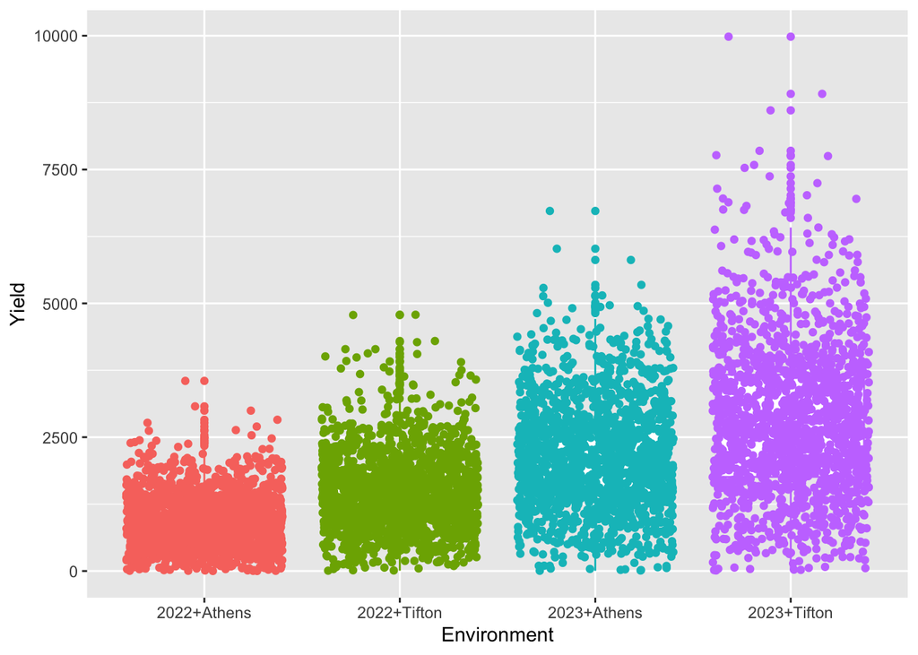

```r
ggplot(rcbd_gsw1, aes(x = e,
                    y = yield,
                    color = e)) +
  geom_boxplot() +
  geom_jitter() +
  theme(legend.position = "none")+
  labs(x = "Environment",
       y = "Yield")
```

- The boxplot shows that highest yield was observed for Tifton followed by Athens in 2023.

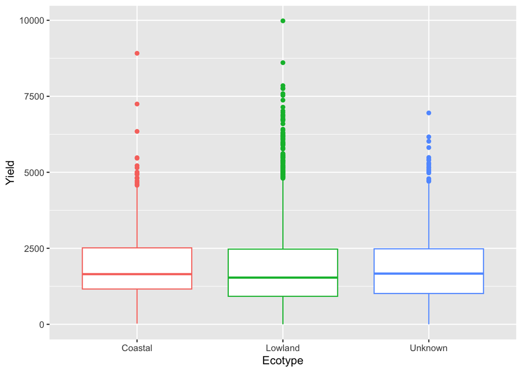

```r
ggplot(rcbd_gsw1, aes(x = ecotype,
                    y = yield,
                    color = ecotype)) +
  geom_boxplot() +
  #geom_jitter() +
  theme(legend.position = "none")+
  labs(x = "Ecotype",
       y = "Yield")
```

The distribution of yield for two different ecotype and the unknown ecotype looks similar. Most of the samples belonged to lowland ecotype.

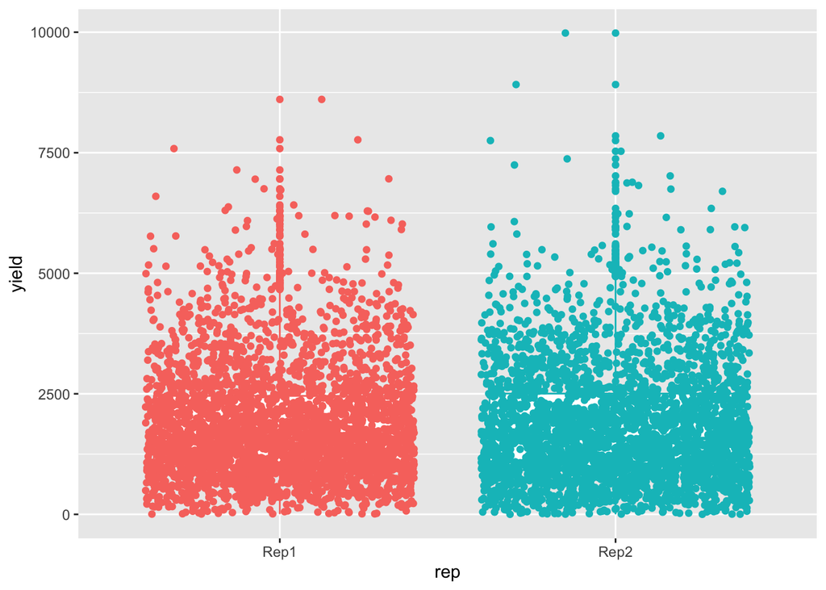

```r
ggplot(rcbd_gsw, aes(x = rep,
                    y = yield,
                    color = rep)) +
  geom_boxplot() +
  geom_jitter() +
  theme(legend.position = "none")
```

The distribution of yield for both of the replication looks similar.

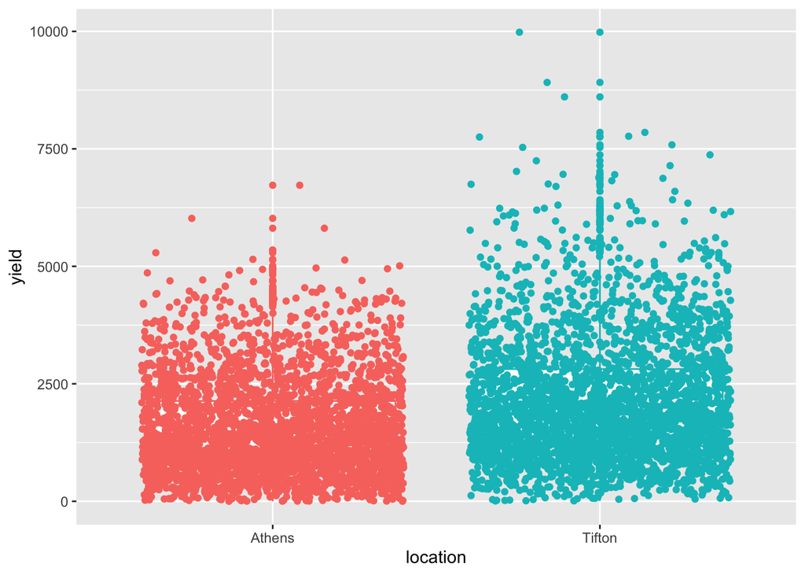

```r
ggplot(rcbd_gsw, aes(x = location,
                    y = yield,
                    color = location)) +
  geom_boxplot() +
  geom_jitter() +
  theme(legend.position = "none")
```

On average, the yield of Tifton is higher than the Athens, regardless of the year.

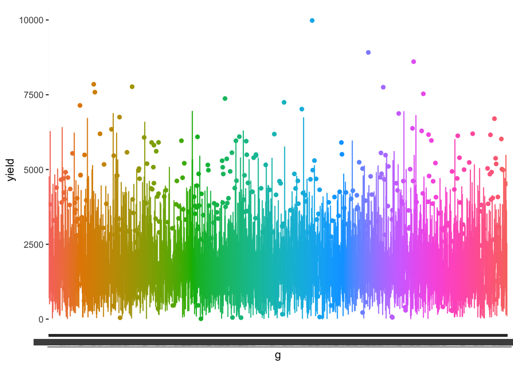

```r
ggplot(rcbd_gsw1, aes(x = g,
                    y = yield,
                    color = g)) +
  geom_boxplot() +
  #geom_jitter() +
  theme(legend.position = "none")
```

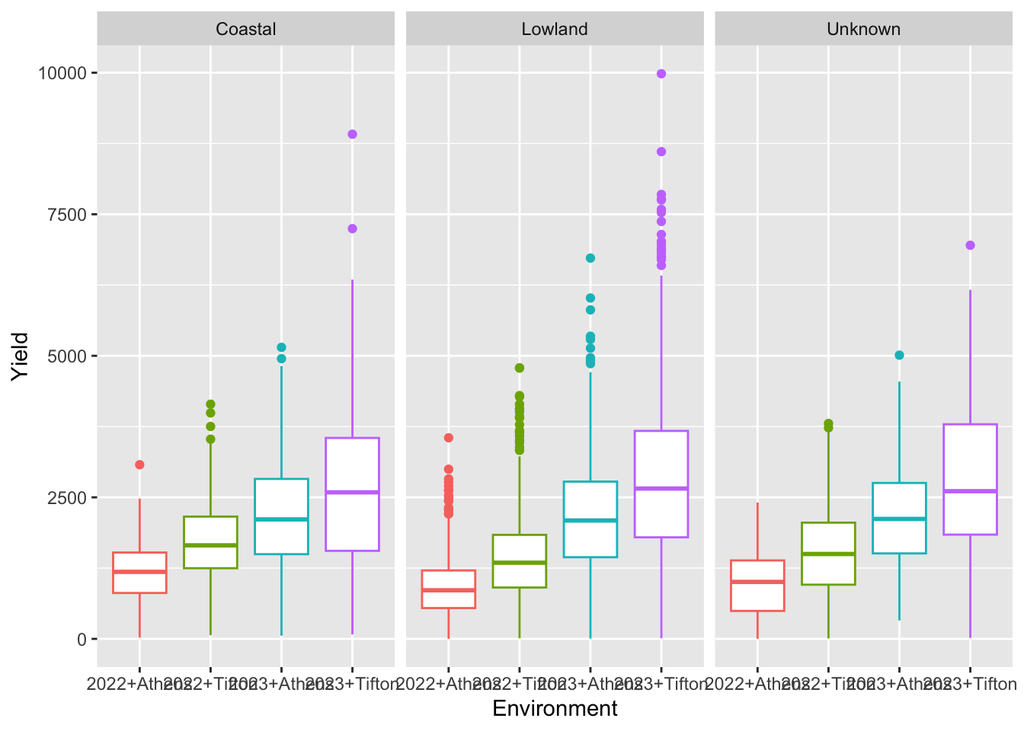

```r
ggplot(rcbd_gsw1, aes(x = e,
                    y = yield,
                    color = e)) +
  geom_boxplot() +
  #geom_jitter() +
  facet_grid(.~ecotype) +
  labs(x = "Environment",
       y = "Yield")+
  theme(legend.position = "none")
```

The distribution of yield for four different environments look similar for the three ecotypes, where Tifton in 2023 had the higher yield followed by Athens in 2023.

# 11 e) Statistical model

```r
#changing to sum-to-zero contrast
options(contrasts = c("contr.sum", "contr.poly"))

# model fitting 1 - fit a mixed-effects model with interaction
library(lme4)

mixed_model1 <- lmer(yield ~ year+
                       location+
                       rep +
                       year*location +
                       (1|hsf) + (1|hsf:year:location),
                     data = rcbd_gsw
                     )
mixed_model1
```

```
Linear mixed model fit by REML ['lmerMod']
Formula: yield ~ year + location + rep + year * location + (1 | hsf) +
    (1 | hsf:year:location)
   Data: rcbd_gsw
REML criterion at convergence: 105498.9
Random effects:
 Groups            Name        Std.Dev.
 hsf:year:location (Intercept) 174.9
 hsf               (Intercept) 154.3
 Residual                      953.9
Number of obs: 6356, groups:  hsf:year:location, 800; hsf, 200
Fixed Effects:
    (Intercept)            year1        location1             rep1
        1841.41          -632.55          -288.67            16.04
year1:location1
          23.77
```

```r
summary(mixed_model1)
```

```
Linear mixed model fit by REML ['lmerMod']
Formula: yield ~ year + location + rep + year * location + (1 | hsf) +
    (1 | hsf:year:location)
   Data: rcbd_gsw

REML criterion at convergence: 105498.9

Scaled residuals:
    Min      1Q  Median      3Q     Max
-2.9715 -0.5652 -0.0626  0.4825  7.3447

Random effects:
 Groups            Name        Variance Std.Dev.
 hsf:year:location (Intercept)  30591   174.9
 hsf               (Intercept)  23816   154.3
 Residual                      909944   953.9
Number of obs: 6356, groups:  hsf:year:location, 800; hsf, 200

Fixed effects:
                Estimate Std. Error t value
(Intercept)      1841.41      17.34 106.220
year1            -632.55      13.47 -46.959
location1        -288.67      13.47 -21.430
rep1               16.04      11.97   1.340
year1:location1    23.77      13.47   1.765

Correlation of Fixed Effects:
            (Intr) year1  loctn1 rep1
year1       -0.003
location1    0.000  0.002
rep1        -0.001 -0.001 -0.003
year1:lctn1  0.002  0.000 -0.003  0.002
```

```r
#changing to sum-to-zero contrast
options(contrasts = c("contr.sum", "contr.poly"))

# model fitting 1 - fit a mixed-effects model with interaction
library(lme4)

mixed_model2 <- lmer(yield ~ year+
                       location+
                       rep +
                       year*location +
                       (1|g) + (1|g:e),
                     data = rcbd_gsw1
                     )
mixed_model2
```

```
Linear mixed model fit by REML ['lmerMod']
Formula: yield ~ year + location + rep + year * location + (1 | g) + (1 |
    g:e)
   Data: rcbd_gsw1
REML criterion at convergence: 105414.5
Random effects:
 Groups   Name        Std.Dev.
 g:e      (Intercept) 298.9
 g        (Intercept) 270.8
 Residual             895.4
Number of obs: 6356, groups:  g:e, 3200; g, 800
Fixed Effects:
   (Intercept)            year       location1            rep1  year:location1
    -2.558e+06       1.266e+03       9.565e+04       1.582e+01      -4.743e+01
fit warnings:
Some predictor variables are on very different scales: consider rescaling
```

```r
summary(mixed_model2)
```

```
Linear mixed model fit by REML ['lmerMod']
Formula: yield ~ year + location + rep + year * location + (1 | g) + (1 |
    g:e)
   Data: rcbd_gsw1

REML criterion at convergence: 105414.5

Scaled residuals:
    Min      1Q  Median      3Q     Max
-3.1667 -0.5300 -0.0476  0.4582  6.8814

Random effects:
 Groups   Name        Variance Std.Dev.
 g:e      (Intercept)  89326   298.9
 g        (Intercept)  73310   270.8
 Residual             801701   895.4
Number of obs: 6356, groups:  g:e, 3200; g, 800

Fixed effects:
                 Estimate Std. Error t value
(Intercept)    -2.558e+06  5.023e+04 -50.936
year            1.266e+03  2.483e+01  50.973
location1       9.565e+04  5.023e+04   1.904
rep1            1.582e+01  1.124e+01   1.408
year:location1 -4.743e+01  2.483e+01  -1.910

Correlation of Fixed Effects:
            (Intr) year   loctn1 rep1
year        -1.000
location1    0.000  0.000
rep1        -0.001  0.001  0.002
year:loctn1  0.000  0.000 -1.000 -0.002
fit warnings:
Some predictor variables are on very different scales: consider rescaling
```

From the above two models, we will use variance components from ‘random effects’ table and use them for the computation of heritability which is given in the next chunks. For variance components we can also use VarCorr function from lme4 package to extract std. deviations and square them for computing variances.

```r
VarComp1 = VarCorr(mixed_model1)

VarComp1
```

```
 Groups            Name        Std.Dev.
 hsf:year:location (Intercept) 174.90
 hsf               (Intercept) 154.32
 Residual                      953.91
```

```r
VarComp2 = VarCorr(mixed_model2)

VarComp2
```

```
 Groups   Name        Std.Dev.
 g:e      (Intercept) 298.87
 g        (Intercept) 270.76
 Residual             895.38
```

```r
# Heritability formula ---> H2 = Vg / Vg + Vge/e + Verror/rep*e
# e = locations = 2
# rep = replications = 2
# Vg = genotypic variance
# Vge = genotype by environment variance
# Verror = error variance


# Groups            Name        Std.Dev.
# hsf:year:location (Intercept) 174.90
# hsf               (Intercept) 154.32
# Residual                      953.91

# variance is the squared std. deviations

# genotype by environment
Vge = (174.90)^2

Vge
```

```
[1] 30590.01
```

```r
Venv = Vge/2

Venv
```

```
[1] 15295
```

```r
# genotypic varanice
Vg = (154.32)^2

Vg
```

```
[1] 23814.66
```

```r
# error varanice
Ve = (953.91)^2

Verror = Ve/4

Verror
```

```
[1] 227486.1
```

```r
Vp = Vg + Venv + Verror

Vp
```

```
[1] 266595.7
```

```r
H2 = Vg / Vp

H2
```

```
[1] 0.08932874
```

Hertability is too low (H2 = 0.08).

```r
# Heritability formula ---> H2 = Vg / Vg + Vge/e + Verror/rep*e
# e = locations = 2
# rep = replications = 2
# Vg = genotypic variance
# Vge = genotype by environment variance
# Verror = error variance


# Groups   Name        Std.Dev.
# g:e      (Intercept) 298.87
# g        (Intercept) 270.76
# Residual             895.38
# variance is the squared std. deviations

# genotype by environment
Vge = (298.87)^2

Vge
```

```
[1] 89323.28
```

```r
Venv = Vge/2

Venv
```

```
[1] 44661.64
```

```r
# genotypic varanice
Vg = (270.76)^2

Vg
```

```
[1] 73310.98
```

```r
# error varanice
Ve = (895.38)^2

Verror = Ve/4

Verror
```

```
[1] 200426.3
```

```r
Vp = Vg + Venv + Verror

Vp
```

```
[1] 318399
```

```r
H2 = Vg / Vp

H2
```

```
[1] 0.2302488
```

# 12 f) ANOVA table

```r
Anova(mixed_model1 , type=3)
```

```
Analysis of Deviance Table (Type III Wald chisquare tests)

Response: yield
                   Chisq Df Pr(>Chisq)
(Intercept)   11282.7531  1    < 2e-16 ***
year           2205.1486  1    < 2e-16 ***
location        459.2303  1    < 2e-16 ***
rep               1.7966  1    0.18012
year:location     3.1148  1    0.07758 .
---
Signif. codes:  0 '***' 0.001 '**' 0.01 '*' 0.05 '.' 0.1 ' ' 1
```

```r
Anova(mixed_model2 , type=3)
```

```
Analysis of Deviance Table (Type III Wald chisquare tests)

Response: yield
                  Chisq Df Pr(>Chisq)
(Intercept)   2594.5072  1    < 2e-16 ***
year          2598.2392  1    < 2e-16 ***
location         3.6266  1    0.05686 .
rep              1.9823  1    0.15915
year:location    3.6485  1    0.05612 .
---
Signif. codes:  0 '***' 0.001 '**' 0.01 '*' 0.05 '.' 0.1 ' ' 1
```

Out of the two ANOVA models, we will prefer model 1 using hsf as random effects parameter which gives the significant effect of years and locations on the overall biomass yield.

# 13 g) Linear model assumptions

## 13.1 Extracting residuals

```r
#install.packages("broom.mixed")
library(broom.mixed)
rcbd_mix_resid1 <- augment(mixed_model1) %>%
  mutate(.studresid=rstudent(mixed_model1))

head(rcbd_mix_resid1,5)
```

```
# A tibble: 5 × 18
  .rownames yield year  location rep   hsf   .fitted .resid   .hat   .cooksd
  <chr>     <dbl> <fct> <fct>    <fct> <fct>   <dbl>  <dbl>  <dbl>     <dbl>
1 1          1079 2022  Athens   Rep1  Fam_1   1016.   63.2 0.0369 0.0000349
2 2           847 2022  Athens   Rep1  Fam_1   1016. -169.  0.0369 0.000249
3 3          1549 2022  Athens   Rep1  Fam_1   1016.  533.  0.0369 0.00249
4 4           790 2022  Athens   Rep1  Fam_1   1016. -226.  0.0369 0.000446
5 5           741 2022  Athens   Rep1  Fam_2   1069. -328.  0.0369 0.000939
# ℹ 8 more variables: .fixed <dbl>, .mu <dbl>, .offset <dbl>, .sqrtXwt <dbl>,
#   .sqrtrwt <dbl>, .weights <dbl>, .wtres <dbl>, .studresid <dbl>
```

# 14 Model Assumptions

- Independence (no pattern)
- Variance homogeneity (homoscedasticity)
- Normality
- Outlier detection (< -3 or > 3)

### 14.0.1 Random effects are iid ~ N(0,var_a)

```r
randeff_rep1 = ranef(mixed_model1)$hsf

head(randeff_rep1,5)
```

```
        (Intercept)
Fam_1      41.62143
Fam_10     35.65747
Fam_100  -153.64663
Fam_101   144.93451
Fam_102   -38.32336
```

```r
randeff_rep1 %>%
  as.data.frame() %>%
  head(5)
```

```
        (Intercept)
Fam_1      41.62143
Fam_10     35.65747
Fam_100  -153.64663
Fam_101   144.93451
Fam_102   -38.32336
```

```r
write.table(randeff_rep1, "r", sep="\t", row.names=F)
```

Reason for computing intercept values is that in plant breeding, the random effect prediction models are used to extract intercept values that are used as best linear unbiased prediction (BLUP) values to which intercept value from the statistical model is added and all the resulting values are sorted from largest to smallest and the top 10% or 20% are selected as the best performers in terms of high predicted yields (a sample of BLUPs table is attached in the data folder highlighting top 20 best performing hsf).

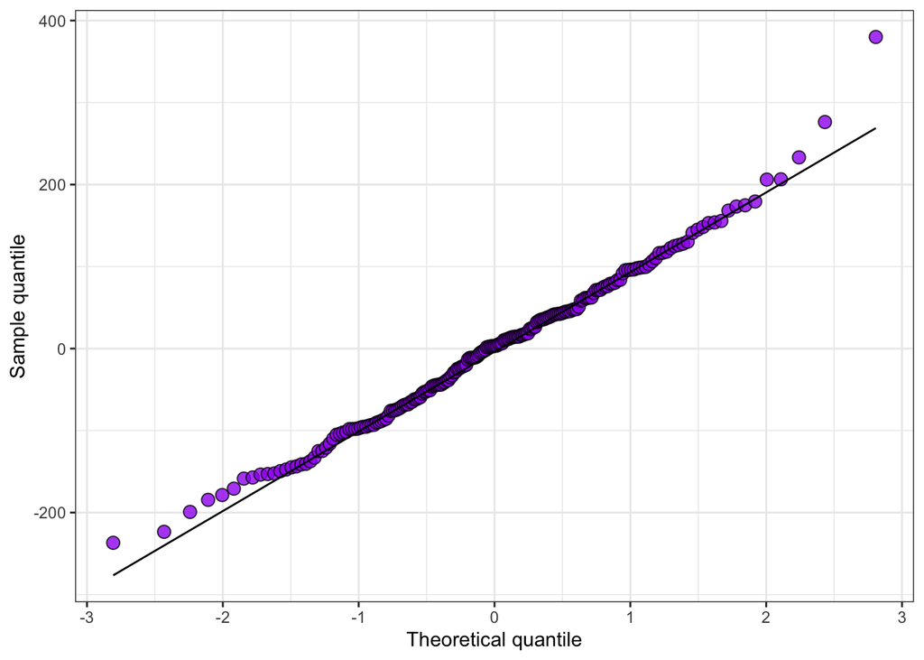

```r
ggplot(randeff_rep1, aes(sample=`(Intercept)`))+
  stat_qq(  shape = 21,
            fill = "purple",
            size = 3,
            alpha = .8
  )+
  stat_qq_line()+
  labs(x = "Theoretical quantile",
       y = "Sample quantile")+
  theme_bw()
```

Looks good.

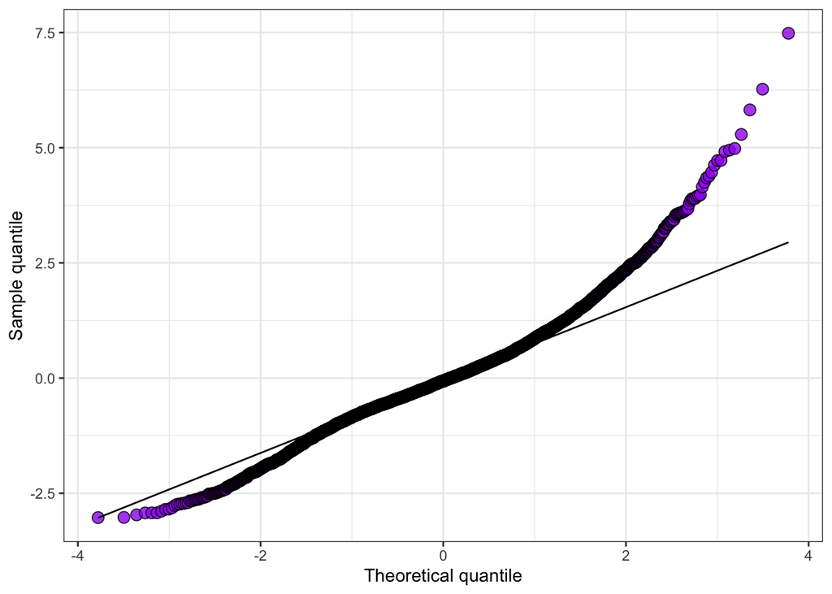

```r
ggplot(rcbd_mix_resid1, aes(sample=.studresid))+
  stat_qq(  shape = 21,
            fill = "purple",
            size = 3,
            alpha = .8
  )+
  stat_qq_line()+
  labs(x = "Theoretical quantile",
       y = "Sample quantile")+
  theme_bw()
```

### 14.0.2 Within-group errors are iid ~ N(0, var_e)

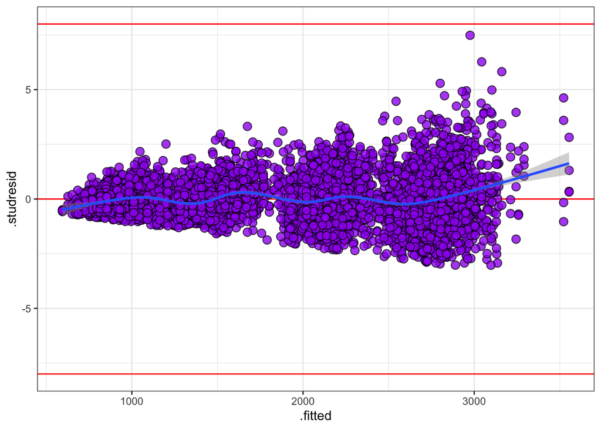

```r
ggplot(rcbd_mix_resid1, aes(x=.fitted, y=.studresid))+
  geom_hline(yintercept = 0, color="red")+
  geom_point(shape = 21,
             fill = "purple",
             size = 3,
             alpha = .8)+
  geom_smooth() +
  geom_hline(yintercept = c(-8, 8), color = "red")+
  theme_bw()
```

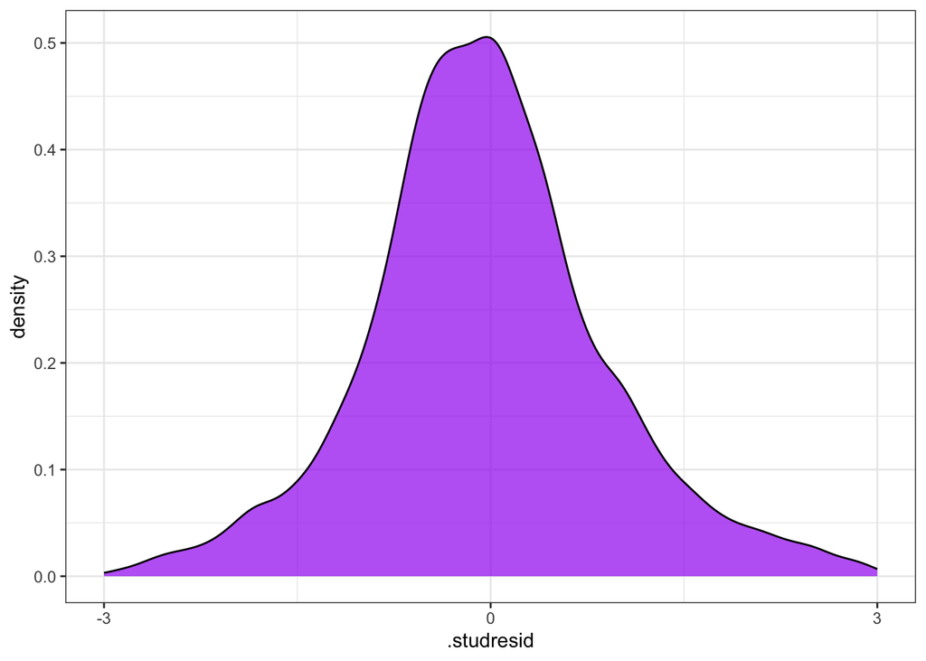

```r
ggplot(rcbd_mix_resid1, aes(x=.studresid))+
  geom_density(color = "black",
               fill = "purple",
               alpha = .7)+
  scale_x_continuous(breaks = c(-3,0,3), limits = c(-3,3))+
  theme_bw()
```

# 15 h) Model means

Extracting the model means.

```r
library(emmeans)

emm_options(pbkrtest.limit = 6356)

LS_means <- emmeans(mixed_model1, ~year + location + rep +
    year*location)

head(LS_means, 5)
```

```
 year location rep  emmean   SE   df lower.CL upper.CL
 2022 Athens   Rep1    960 31.4 1019      898     1022
 2023 Athens   Rep1   2178 31.4 1022     2116     2239
 2022 Tifton   Rep1   1490 31.4 1016     1428     1551
 2023 Tifton   Rep1   2802 31.5 1032     2741     2864
 2022 Athens   Rep2    928 31.4 1023      866      990

Degrees-of-freedom method: kenward-roger
Confidence level used: 0.95
```

# 16 i) Pairwise comparisons

```r
library(multcompView)
library(multcomp)

meansComb1<- cld(LS_means,
                   reversed=T,
                   adjust="none",
               Letters=letters)
head(meansComb1,5)
```

```
 year location rep  emmean   SE   df lower.CL upper.CL .group
 2023 Tifton   Rep1   2802 31.5 1032     2741     2864  a
 2023 Tifton   Rep2   2770 31.5 1027     2709     2832  a
 2023 Athens   Rep1   2178 31.4 1022     2116     2239   b
 2023 Athens   Rep2   2145 31.5 1027     2084     2207   b
 2022 Tifton   Rep1   1490 31.4 1016     1428     1551    c

Degrees-of-freedom method: kenward-roger
Confidence level used: 0.95
significance level used: alpha = 0.05
NOTE: If two or more means share the same grouping symbol,
      then we cannot show them to be different.
      But we also did not show them to be the same.
```

```r
selected = meansComb1 %>%
  as.data.frame() %>%
  mutate(letter = trimws(.group))


head(selected,5)
```

```
  year location  rep   emmean       SE       df lower.CL upper.CL .group letter
5 2023   Tifton Rep1 2802.446 31.52651 1032.350 2740.583 2864.310   a         a
1 2023   Tifton Rep2 2770.365 31.47681 1027.303 2708.599 2832.132   a         a
7 2023   Athens Rep1 2177.565 31.42423 1021.878 2115.901 2239.228    b        b
3 2023   Athens Rep2 2145.484 31.46593 1026.673 2083.739 2207.229    b        b
6 2022   Tifton Rep1 1489.792 31.37111 1015.777 1428.232 1551.351     c       c
```

# 17 g) Final plot

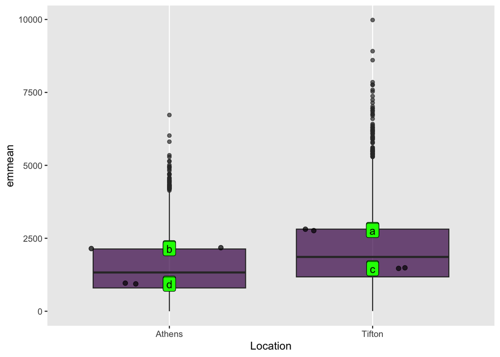

```r
ggplot(mapping = aes(fill = "location")) +
  # Raw data and boxplots
  geom_boxplot(data = rcbd_gsw,
               aes(x = location,
                   y = yield),
               alpha = .7) +
  geom_jitter(data = selected,
               aes(x = location,
                   y = emmean),
              shape = 20,
              size = 3,
              alpha = .7) +
  geom_label(data = selected,
             aes(x = location,
                 y = emmean,
                 label = letter), fill = "green") +
  labs(data = selected,
       x = "Location",
       y = "emmean") +
  scale_fill_viridis_d() +
  theme(legend.position = "none",
        panel.grid.major.y = element_blank(),
        panel.grid.minor.y = element_blank()
        )
```

```r
selected
```

```
  year location  rep    emmean       SE       df  lower.CL  upper.CL .group
5 2023   Tifton Rep1 2802.4464 31.52651 1032.350 2740.5830 2864.3098   a
1 2023   Tifton Rep2 2770.3655 31.47681 1027.303 2708.5993 2832.1316   a
7 2023   Athens Rep1 2177.5648 31.42423 1021.878 2115.9014 2239.2282    b
3 2023   Athens Rep2 2145.4838 31.46593 1026.673 2083.7389 2207.2287    b
6 2022   Tifton Rep1 1489.7917 31.37111 1015.777 1428.2321 1551.3513     c
2 2022   Tifton Rep2 1457.7107 31.37704 1016.451 1396.1395 1519.2819     c
8 2022   Athens Rep1  960.0042 31.39761 1018.811  898.3929 1021.6156      d
4 2022   Athens Rep2  927.9233 31.43325 1022.891  866.2423  989.6043      d
  letter
5      a
1      a
7      b
3      b
6      c
2      c
8      d
4      d
```

```r
ggsave("../Output//ggplot_GS.png",
       width = 8,
       height = 5)
```

# 18 Team work in GitHub

Whether you are working with your future-self or as duos, make sure to stage, commit, and push after finishing each of the sub-sections above. When committing, write commit messages that are short and descriptive (e.g., finished wrangling).

If you are working in duos, make sure to split the workload. I will check your collaborative work through the commit history, and if one student has contributed significantly more than the other, than that will impact grades.

**Tip 1**: to avoid merge conflicts, make sure to **pull** first, and then start working locally. That will ensure that any changes made by your partner will be “downloaded” before you make changes to the files locally.

**Tip 2**: make use of the Issues on this repository to set up to-do lists and assign tasks to different people. You can also use each issue/task to discuss how things should be run and get to an agreement.

# 19 Submitting your work

Once you have developed all the code and answers, make sure to Render this quarto file.

**Notes on rendering**:

- Make sure to render your work and inspect how the final html look like.
- If it does not look professional for whatever reason, then fix the issue, re-render it, recheck.
- Only send me your work once your html file looks professional.
- Some potential issues you may encounter and how to fix them:
  - Some times your code may be creating a table output that is waaay to long and cumbersome to scroll through when rendered. If this is the case, make it more professional looking by using the `head()` function to only print the first handful of rows (instead of thousands of rows).
  - **DO NOT** delete the file’s heading levels (# and ##). They set up the proper heading 1 and 2 levels, and I use them to guide my grading.
  - If a given chunk is also outputting warnings or messages, inhibit this behavior by changing the chunk options `message` and `warning` to `FALSE`.
  - If, after rendered, 2 lines of text are connected and you wish to “break line” between them, add 2 extra spaces after the first one.

After rendering, an .html file will be created on your `code` folder.

Rename this file to `LASTNAME1-LASTNAME2_midtermproject.html`.  
For ex., `Bastos-Mendes_midtermproject.html`.

Send the html file to my email (lmbastos@uga.edu) by **April 11th** 11:59 pm.